# Optimal Treatment Analysis

## Outcome Variable

**Outcome Variable:** whz

## Predictor Variables

**Intervention Variable:** earlybf

**Adjustment Set:**

- arm
- sex
- W_mage
- meducyrs
- feducyrs
- hhwealth_quart
- hfoodsec
- W_mhtcm
- vagbrth
- W_birthwt
- W_birthlen
- W_nrooms
- W_nchldlt5
- brthmon
- W_parity
- impfloor
- impsan
- safeh20
- delta_W_mage
- delta_meducyrs
- delta_feducyrs
- delta_hhwealth_quart
- delta_hfoodsec
- delta_W_mhtcm
- delta_vagbrth
- delta_W_birthwt
- delta_W_birthlen
- delta_W_nrooms
- delta_W_nchldlt5
- delta_brthmon
- delta_W_parity
- delta_impfloor
- delta_impsan
- delta_safeh20

## Stratifying Variables

The analysis was stratified on these variable(s):

- agecat
- studyid
- country

## Data Summary

| agecat | studyid | country | earlybf | n_cell | n |
| --- | --- | --- | --- | --- | --- |
| Birth | ki0047075b-MAL-ED | BANGLADESH | 1 | 152 | 240 |
| Birth | ki0047075b-MAL-ED | BANGLADESH | 0 | 88 | 240 |
| Birth | ki0047075b-MAL-ED | BRAZIL | 1 | 79 | 183 |
| Birth | ki0047075b-MAL-ED | BRAZIL | 0 | 104 | 183 |
| Birth | ki0047075b-MAL-ED | INDIA | 1 | 123 | 202 |
| Birth | ki0047075b-MAL-ED | INDIA | 0 | 79 | 202 |
| Birth | ki0047075b-MAL-ED | NEPAL | 1 | 77 | 168 |
| Birth | ki0047075b-MAL-ED | NEPAL | 0 | 91 | 168 |
| Birth | ki0047075b-MAL-ED | PERU | 1 | 211 | 279 |
| Birth | ki0047075b-MAL-ED | PERU | 0 | 68 | 279 |
| Birth | ki0047075b-MAL-ED | SOUTH AFRICA | 1 | 154 | 245 |
| Birth | ki0047075b-MAL-ED | SOUTH AFRICA | 0 | 91 | 245 |
| Birth | ki0047075b-MAL-ED | TANZANIA, UNITED REPUBLIC OF | 1 | 108 | 118 |
| Birth | ki0047075b-MAL-ED | TANZANIA, UNITED REPUBLIC OF | 0 | 10 | 118 |
| Birth | ki1000109-EE | PAKISTAN | 1 | 1 | 1 |
| Birth | ki1000109-EE | PAKISTAN | 0 | 0 | 1 |
| Birth | ki1000304b-SAS-CompFeed | INDIA | 1 | 13 | 158 |
| Birth | ki1000304b-SAS-CompFeed | INDIA | 0 | 145 | 158 |
| Birth | ki1017093c-NIH-Crypto | BANGLADESH | 1 | 19 | 23 |
| Birth | ki1017093c-NIH-Crypto | BANGLADESH | 0 | 4 | 23 |
| Birth | ki1126311-ZVITAMBO | ZIMBABWE | 1 | 6141 | 11513 |
| Birth | ki1126311-ZVITAMBO | ZIMBABWE | 0 | 5372 | 11513 |
| Birth | kiGH5241-JiVitA-3 | BANGLADESH | 1 | 93 | 15648 |
| Birth | kiGH5241-JiVitA-3 | BANGLADESH | 0 | 15555 | 15648 |
| Birth | kiGH5241-JiVitA-4 | BANGLADESH | 1 | 475 | 683 |
| Birth | kiGH5241-JiVitA-4 | BANGLADESH | 0 | 208 | 683 |
| 6 months | ki0047075b-MAL-ED | BANGLADESH | 1 | 147 | 240 |
| 6 months | ki0047075b-MAL-ED | BANGLADESH | 0 | 93 | 240 |
| 6 months | ki0047075b-MAL-ED | BRAZIL | 1 | 95 | 209 |
| 6 months | ki0047075b-MAL-ED | BRAZIL | 0 | 114 | 209 |
| 6 months | ki0047075b-MAL-ED | INDIA | 1 | 140 | 236 |
| 6 months | ki0047075b-MAL-ED | INDIA | 0 | 96 | 236 |
| 6 months | ki0047075b-MAL-ED | NEPAL | 1 | 96 | 236 |
| 6 months | ki0047075b-MAL-ED | NEPAL | 0 | 140 | 236 |
| 6 months | ki0047075b-MAL-ED | PERU | 1 | 202 | 273 |
| 6 months | ki0047075b-MAL-ED | PERU | 0 | 71 | 273 |
| 6 months | ki0047075b-MAL-ED | SOUTH AFRICA | 1 | 156 | 250 |
| 6 months | ki0047075b-MAL-ED | SOUTH AFRICA | 0 | 94 | 250 |
| 6 months | ki0047075b-MAL-ED | TANZANIA, UNITED REPUBLIC OF | 1 | 205 | 247 |
| 6 months | ki0047075b-MAL-ED | TANZANIA, UNITED REPUBLIC OF | 0 | 42 | 247 |
| 6 months | ki1000109-EE | PAKISTAN | 1 | 69 | 376 |
| 6 months | ki1000109-EE | PAKISTAN | 0 | 307 | 376 |
| 6 months | ki1000304b-SAS-CompFeed | INDIA | 1 | 97 | 1334 |
| 6 months | ki1000304b-SAS-CompFeed | INDIA | 0 | 1237 | 1334 |
| 6 months | ki1017093c-NIH-Crypto | BANGLADESH | 1 | 619 | 715 |
| 6 months | ki1017093c-NIH-Crypto | BANGLADESH | 0 | 96 | 715 |
| 6 months | ki1113344-GMS-Nepal | NEPAL | 1 | 151 | 510 |
| 6 months | ki1113344-GMS-Nepal | NEPAL | 0 | 359 | 510 |
| 6 months | ki1126311-ZVITAMBO | ZIMBABWE | 1 | 3951 | 7339 |
| 6 months | ki1126311-ZVITAMBO | ZIMBABWE | 0 | 3388 | 7339 |
| 6 months | kiGH5241-JiVitA-3 | BANGLADESH | 1 | 36 | 16784 |
| 6 months | kiGH5241-JiVitA-3 | BANGLADESH | 0 | 16748 | 16784 |
| 6 months | kiGH5241-JiVitA-4 | BANGLADESH | 1 | 3095 | 4833 |
| 6 months | kiGH5241-JiVitA-4 | BANGLADESH | 0 | 1738 | 4833 |
| 24 months | ki0047075b-MAL-ED | BANGLADESH | 1 | 128 | 211 |
| 24 months | ki0047075b-MAL-ED | BANGLADESH | 0 | 83 | 211 |
| 24 months | ki0047075b-MAL-ED | BRAZIL | 1 | 80 | 169 |
| 24 months | ki0047075b-MAL-ED | BRAZIL | 0 | 89 | 169 |
| 24 months | ki0047075b-MAL-ED | INDIA | 1 | 134 | 227 |
| 24 months | ki0047075b-MAL-ED | INDIA | 0 | 93 | 227 |
| 24 months | ki0047075b-MAL-ED | NEPAL | 1 | 95 | 228 |
| 24 months | ki0047075b-MAL-ED | NEPAL | 0 | 133 | 228 |
| 24 months | ki0047075b-MAL-ED | PERU | 1 | 149 | 201 |
| 24 months | ki0047075b-MAL-ED | PERU | 0 | 52 | 201 |
| 24 months | ki0047075b-MAL-ED | SOUTH AFRICA | 1 | 144 | 235 |
| 24 months | ki0047075b-MAL-ED | SOUTH AFRICA | 0 | 91 | 235 |
| 24 months | ki0047075b-MAL-ED | TANZANIA, UNITED REPUBLIC OF | 1 | 180 | 214 |
| 24 months | ki0047075b-MAL-ED | TANZANIA, UNITED REPUBLIC OF | 0 | 34 | 214 |
| 24 months | ki1017093c-NIH-Crypto | BANGLADESH | 1 | 443 | 514 |
| 24 months | ki1017093c-NIH-Crypto | BANGLADESH | 0 | 71 | 514 |
| 24 months | ki1113344-GMS-Nepal | NEPAL | 1 | 136 | 454 |
| 24 months | ki1113344-GMS-Nepal | NEPAL | 0 | 318 | 454 |
| 24 months | ki1126311-ZVITAMBO | ZIMBABWE | 1 | 198 | 370 |
| 24 months | ki1126311-ZVITAMBO | ZIMBABWE | 0 | 172 | 370 |
| 24 months | kiGH5241-JiVitA-3 | BANGLADESH | 1 | 1 | 8603 |
| 24 months | kiGH5241-JiVitA-3 | BANGLADESH | 0 | 8602 | 8603 |
| 24 months | kiGH5241-JiVitA-4 | BANGLADESH | 1 | 3031 | 4735 |
| 24 months | kiGH5241-JiVitA-4 | BANGLADESH | 0 | 1704 | 4735 |

The following strata were considered:

- agecat: 24 months, studyid: ki0047075b-MAL-ED, country: BANGLADESH
- agecat: 24 months, studyid: ki0047075b-MAL-ED, country: BRAZIL
- agecat: 24 months, studyid: ki0047075b-MAL-ED, country: INDIA
- agecat: 24 months, studyid: ki0047075b-MAL-ED, country: NEPAL
- agecat: 24 months, studyid: ki0047075b-MAL-ED, country: PERU
- agecat: 24 months, studyid: ki0047075b-MAL-ED, country: SOUTH AFRICA
- agecat: 24 months, studyid: ki0047075b-MAL-ED, country: TANZANIA, UNITED REPUBLIC OF
- agecat: 24 months, studyid: ki1017093c-NIH-Crypto, country: BANGLADESH
- agecat: 24 months, studyid: ki1113344-GMS-Nepal, country: NEPAL
- agecat: 24 months, studyid: ki1126311-ZVITAMBO, country: ZIMBABWE
- agecat: 24 months, studyid: kiGH5241-JiVitA-3, country: BANGLADESH
- agecat: 24 months, studyid: kiGH5241-JiVitA-4, country: BANGLADESH
- agecat: 6 months, studyid: ki0047075b-MAL-ED, country: BANGLADESH
- agecat: 6 months, studyid: ki0047075b-MAL-ED, country: BRAZIL
- agecat: 6 months, studyid: ki0047075b-MAL-ED, country: INDIA
- agecat: 6 months, studyid: ki0047075b-MAL-ED, country: NEPAL
- agecat: 6 months, studyid: ki0047075b-MAL-ED, country: PERU
- agecat: 6 months, studyid: ki0047075b-MAL-ED, country: SOUTH AFRICA
- agecat: 6 months, studyid: ki0047075b-MAL-ED, country: TANZANIA, UNITED REPUBLIC OF
- agecat: 6 months, studyid: ki1000109-EE, country: PAKISTAN
- agecat: 6 months, studyid: ki1000304b-SAS-CompFeed, country: INDIA
- agecat: 6 months, studyid: ki1017093c-NIH-Crypto, country: BANGLADESH
- agecat: 6 months, studyid: ki1113344-GMS-Nepal, country: NEPAL
- agecat: 6 months, studyid: ki1126311-ZVITAMBO, country: ZIMBABWE
- agecat: 6 months, studyid: kiGH5241-JiVitA-3, country: BANGLADESH
- agecat: 6 months, studyid: kiGH5241-JiVitA-4, country: BANGLADESH
- agecat: Birth, studyid: ki0047075b-MAL-ED, country: BANGLADESH
- agecat: Birth, studyid: ki0047075b-MAL-ED, country: BRAZIL
- agecat: Birth, studyid: ki0047075b-MAL-ED, country: INDIA
- agecat: Birth, studyid: ki0047075b-MAL-ED, country: NEPAL
- agecat: Birth, studyid: ki0047075b-MAL-ED, country: PERU
- agecat: Birth, studyid: ki0047075b-MAL-ED, country: SOUTH AFRICA
- agecat: Birth, studyid: ki0047075b-MAL-ED, country: TANZANIA, UNITED REPUBLIC OF
- agecat: Birth, studyid: ki1000109-EE, country: PAKISTAN
- agecat: Birth, studyid: ki1000304b-SAS-CompFeed, country: INDIA
- agecat: Birth, studyid: ki1017093c-NIH-Crypto, country: BANGLADESH
- agecat: Birth, studyid: ki1126311-ZVITAMBO, country: ZIMBABWE
- agecat: Birth, studyid: kiGH5241-JiVitA-3, country: BANGLADESH
- agecat: Birth, studyid: kiGH5241-JiVitA-4, country: BANGLADESH

### Dropped Strata

Some strata were dropped due to rare outcomes:

- agecat: Birth, studyid: ki1000109-EE, country: PAKISTAN
- agecat: Birth, studyid: ki1017093c-NIH-Crypto, country: BANGLADESH
- agecat: 24 months, studyid: kiGH5241-JiVitA-3, country: BANGLADESH

## Methods Detail

We’re interested in the causal parameters $E[Y_a]$ for all values of $a \in \mathcal{A}$. These parameters represent the mean outcome if, possibly contrary to fact, we intervened to set all units to have $A=a$. Under the randomization and positivity assumptions, these are identified by the statistical parameters $\psi_a=E_W[E_{Y|A,W}(Y|A=a,W)]$. In addition, we’re interested in the mean of $Y$, $E[Y]$ under no intervention (the observed mean). We will estimate these parameters by using SuperLearner to fit the relevant likelihood factors – $E_{Y|A,W}(Y|A=a,W)$ and $p(A=a|W)$, and then updating our likelihood fit using a joint TMLE.

For unadjusted analyses ($W=\{\}$), initial likelihoods were estimated using Lrnr_glm to estimate the simple $E(Y|A)$ and Lrnr_mean to estimate $p(A)$. For adjusted analyses, a small library containing Lrnr_glmnet, Lrnr_xgboost, and Lrnr_mean was used.

# Results Detail

## Results Plots

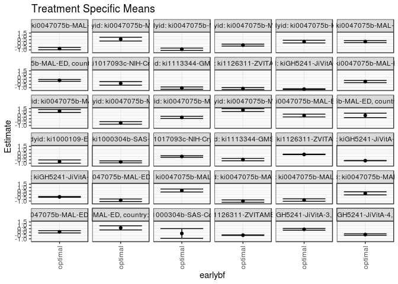

## Results Table

### Parameter: TSM

| agecat | studyid | country | intervention_level | baseline_level | estimate | ci_lower | ci_upper |
| --- | --- | --- | --- | --- | --- | --- | --- |
| Birth | ki0047075b-MAL-ED | BANGLADESH | optimal | observed | -0.8850396 | -1.0711365 | -0.6989428 |
| Birth | ki0047075b-MAL-ED | BRAZIL | optimal | observed | 0.5581591 | 0.3380072 | 0.7783111 |
| Birth | ki0047075b-MAL-ED | INDIA | optimal | observed | -1.0069881 | -1.1838574 | -0.8301189 |
| Birth | ki0047075b-MAL-ED | NEPAL | optimal | observed | -0.8519304 | -1.0321526 | -0.6717083 |
| Birth | ki0047075b-MAL-ED | PERU | optimal | observed | 0.1380764 | -0.0899360 | 0.3660888 |
| Birth | ki0047075b-MAL-ED | SOUTH AFRICA | optimal | observed | 0.0450008 | -0.1271334 | 0.2171350 |
| Birth | ki0047075b-MAL-ED | TANZANIA, UNITED REPUBLIC OF | optimal | observed | 0.6225949 | 0.3172057 | 0.9279840 |
| Birth | ki1000304b-SAS-CompFeed | INDIA | optimal | observed | -0.2058954 | -0.9242553 | 0.5124645 |
| Birth | ki1126311-ZVITAMBO | ZIMBABWE | optimal | observed | -0.4591691 | -0.4949453 | -0.4233929 |
| Birth | kiGH5241-JiVitA-3 | BANGLADESH | optimal | observed | 0.4055800 | 0.2773721 | 0.5337879 |
| Birth | kiGH5241-JiVitA-4 | BANGLADESH | optimal | observed | -0.3661831 | -0.4736225 | -0.2587438 |
| 6 months | ki0047075b-MAL-ED | BANGLADESH | optimal | observed | -0.0907066 | -0.2547668 | 0.0733536 |
| 6 months | ki0047075b-MAL-ED | BRAZIL | optimal | observed | 1.1381281 | 0.9221646 | 1.3540916 |
| 6 months | ki0047075b-MAL-ED | INDIA | optimal | observed | -0.6216267 | -0.8117593 | -0.4314941 |
| 6 months | ki0047075b-MAL-ED | NEPAL | optimal | observed | 0.1912513 | 0.0252873 | 0.3572152 |
| 6 months | ki0047075b-MAL-ED | PERU | optimal | observed | 1.2798173 | 1.0649912 | 1.4946434 |
| 6 months | ki0047075b-MAL-ED | SOUTH AFRICA | optimal | observed | 0.4733583 | 0.2648849 | 0.6818316 |
| 6 months | ki0047075b-MAL-ED | TANZANIA, UNITED REPUBLIC OF | optimal | observed | 0.4952955 | 0.1688418 | 0.8217491 |
| 6 months | ki1000109-EE | PAKISTAN | optimal | observed | -0.7495252 | -0.9869417 | -0.5121088 |
| 6 months | ki1000304b-SAS-CompFeed | INDIA | optimal | observed | -0.7970268 | -0.9459939 | -0.6480598 |
| 6 months | ki1017093c-NIH-Crypto | BANGLADESH | optimal | observed | 0.0067611 | -0.1118586 | 0.1253808 |
| 6 months | ki1113344-GMS-Nepal | NEPAL | optimal | observed | -0.4535978 | -0.6346895 | -0.2725062 |
| 6 months | ki1126311-ZVITAMBO | ZIMBABWE | optimal | observed | 0.3099821 | 0.2712145 | 0.3487497 |
| 6 months | kiGH5241-JiVitA-3 | BANGLADESH | optimal | observed | -0.6134251 | -0.6360858 | -0.5907643 |
| 6 months | kiGH5241-JiVitA-4 | BANGLADESH | optimal | observed | -0.3843611 | -0.4403251 | -0.3283970 |
| 24 months | ki0047075b-MAL-ED | BANGLADESH | optimal | observed | -0.8116605 | -0.9818597 | -0.6414612 |
| 24 months | ki0047075b-MAL-ED | BRAZIL | optimal | observed | 0.5913376 | 0.3130557 | 0.8696195 |
| 24 months | ki0047075b-MAL-ED | INDIA | optimal | observed | -0.9043436 | -1.0759878 | -0.7326994 |
| 24 months | ki0047075b-MAL-ED | NEPAL | optimal | observed | -0.2914840 | -0.4367669 | -0.1462012 |
| 24 months | ki0047075b-MAL-ED | PERU | optimal | observed | 0.2274766 | 0.0312318 | 0.4237214 |
| 24 months | ki0047075b-MAL-ED | SOUTH AFRICA | optimal | observed | 0.2308636 | 0.0803811 | 0.3813462 |
| 24 months | ki0047075b-MAL-ED | TANZANIA, UNITED REPUBLIC OF | optimal | observed | 0.0800481 | -0.0544657 | 0.2145619 |
| 24 months | ki1017093c-NIH-Crypto | BANGLADESH | optimal | observed | -0.3615571 | -0.6290127 | -0.0941015 |
| 24 months | ki1113344-GMS-Nepal | NEPAL | optimal | observed | -1.0594069 | -1.2269815 | -0.8918323 |
| 24 months | ki1126311-ZVITAMBO | ZIMBABWE | optimal | observed | -1.1328122 | -1.2836452 | -0.9819791 |
| 24 months | kiGH5241-JiVitA-4 | BANGLADESH | optimal | observed | -1.2124320 | -1.2619243 | -1.1629396 |

### Parameter: E(Y)

| agecat | studyid | country | intervention_level | baseline_level | estimate | ci_lower | ci_upper |
| --- | --- | --- | --- | --- | --- | --- | --- |
| Birth | ki0047075b-MAL-ED | BANGLADESH | observed | observed | -0.9606667 | -1.0969945 | -0.8243389 |
| Birth | ki0047075b-MAL-ED | BRAZIL | observed | observed | 0.4038798 | 0.2296279 | 0.5781316 |
| Birth | ki0047075b-MAL-ED | INDIA | observed | observed | -1.0653960 | -1.2046419 | -0.9261502 |
| Birth | ki0047075b-MAL-ED | NEPAL | observed | observed | -0.9044643 | -1.0439568 | -0.7649718 |
| Birth | ki0047075b-MAL-ED | PERU | observed | observed | -0.0735842 | -0.1836203 | 0.0364518 |
| Birth | ki0047075b-MAL-ED | SOUTH AFRICA | observed | observed | -0.0415102 | -0.1884529 | 0.1054324 |
| Birth | ki0047075b-MAL-ED | TANZANIA, UNITED REPUBLIC OF | observed | observed | 0.7932203 | 0.5962220 | 0.9902187 |
| Birth | ki1000304b-SAS-CompFeed | INDIA | observed | observed | -0.2577848 | -0.5195618 | 0.0039922 |
| Birth | ki1126311-ZVITAMBO | ZIMBABWE | observed | observed | -0.5258212 | -0.5533316 | -0.4983109 |
| Birth | kiGH5241-JiVitA-3 | BANGLADESH | observed | observed | -0.7240919 | -0.7439633 | -0.7042204 |
| Birth | kiGH5241-JiVitA-4 | BANGLADESH | observed | observed | -0.3683163 | -0.4490504 | -0.2875821 |
| 6 months | ki0047075b-MAL-ED | BANGLADESH | observed | observed | -0.1337535 | -0.2628178 | -0.0046891 |
| 6 months | ki0047075b-MAL-ED | BRAZIL | observed | observed | 0.9717225 | 0.8073791 | 1.1360658 |
| 6 months | ki0047075b-MAL-ED | INDIA | observed | observed | -0.7033969 | -0.8285284 | -0.5782654 |
| 6 months | ki0047075b-MAL-ED | NEPAL | observed | observed | 0.1110452 | -0.0202712 | 0.2423616 |
| 6 months | ki0047075b-MAL-ED | PERU | observed | observed | 1.0543956 | 0.9326967 | 1.1760945 |
| 6 months | ki0047075b-MAL-ED | SOUTH AFRICA | observed | observed | 0.5499200 | 0.3963965 | 0.7034435 |
| 6 months | ki0047075b-MAL-ED | TANZANIA, UNITED REPUBLIC OF | observed | observed | 0.5170513 | 0.3872178 | 0.6468847 |
| 6 months | ki1000109-EE | PAKISTAN | observed | observed | -0.7212766 | -0.8346857 | -0.6078675 |
| 6 months | ki1000304b-SAS-CompFeed | INDIA | observed | observed | -0.6657084 | -0.8024377 | -0.5289791 |
| 6 months | ki1017093c-NIH-Crypto | BANGLADESH | observed | observed | 0.0297622 | -0.0491685 | 0.1086930 |
| 6 months | ki1113344-GMS-Nepal | NEPAL | observed | observed | -0.5853922 | -0.6772967 | -0.4934876 |
| 6 months | ki1126311-ZVITAMBO | ZIMBABWE | observed | observed | 0.3021399 | 0.2744461 | 0.3298338 |
| 6 months | kiGH5241-JiVitA-3 | BANGLADESH | observed | observed | -0.5935161 | -0.6130518 | -0.5739805 |
| 6 months | kiGH5241-JiVitA-4 | BANGLADESH | observed | observed | -0.3898055 | -0.4270507 | -0.3525603 |
| 24 months | ki0047075b-MAL-ED | BANGLADESH | observed | observed | -0.8157109 | -0.9379759 | -0.6934459 |
| 24 months | ki0047075b-MAL-ED | BRAZIL | observed | observed | 0.4466272 | 0.2416144 | 0.6516401 |
| 24 months | ki0047075b-MAL-ED | INDIA | observed | observed | -0.9522907 | -1.0676596 | -0.8369219 |
| 24 months | ki0047075b-MAL-ED | NEPAL | observed | observed | -0.3764474 | -0.4898516 | -0.2630431 |
| 24 months | ki0047075b-MAL-ED | PERU | observed | observed | 0.1199005 | -0.0000331 | 0.2398341 |
| 24 months | ki0047075b-MAL-ED | SOUTH AFRICA | observed | observed | 0.4331915 | 0.3126798 | 0.5537032 |
| 24 months | ki0047075b-MAL-ED | TANZANIA, UNITED REPUBLIC OF | observed | observed | 0.0500935 | -0.0748234 | 0.1750103 |
| 24 months | ki1017093c-NIH-Crypto | BANGLADESH | observed | observed | -0.6103502 | -0.7050157 | -0.5156847 |
| 24 months | ki1113344-GMS-Nepal | NEPAL | observed | observed | -1.1298678 | -1.2212513 | -1.0384844 |
| 24 months | ki1126311-ZVITAMBO | ZIMBABWE | observed | observed | -1.1963784 | -1.3049250 | -1.0878318 |
| 24 months | kiGH5241-JiVitA-4 | BANGLADESH | observed | observed | -1.2231088 | -1.2549632 | -1.1912543 |

### Parameter: PAR

| agecat | studyid | country | intervention_level | baseline_level | estimate | ci_lower | ci_upper |
| --- | --- | --- | --- | --- | --- | --- | --- |
| Birth | ki0047075b-MAL-ED | BANGLADESH | optimal | observed | -0.0756270 | -0.2108255 | 0.0595715 |
| Birth | ki0047075b-MAL-ED | BRAZIL | optimal | observed | -0.1542793 | -0.3235408 | 0.0149821 |
| Birth | ki0047075b-MAL-ED | INDIA | optimal | observed | -0.0584079 | -0.1706139 | 0.0537980 |
| Birth | ki0047075b-MAL-ED | NEPAL | optimal | observed | -0.0525339 | -0.1697747 | 0.0647070 |
| Birth | ki0047075b-MAL-ED | PERU | optimal | observed | -0.2116606 | -0.4099687 | -0.0133525 |
| Birth | ki0047075b-MAL-ED | SOUTH AFRICA | optimal | observed | -0.0865110 | -0.2058396 | 0.0328177 |
| Birth | ki0047075b-MAL-ED | TANZANIA, UNITED REPUBLIC OF | optimal | observed | 0.1706255 | -0.1021822 | 0.4434332 |
| Birth | ki1000304b-SAS-CompFeed | INDIA | optimal | observed | -0.0518894 | -0.5588981 | 0.4551193 |
| Birth | ki1126311-ZVITAMBO | ZIMBABWE | optimal | observed | -0.0666521 | -0.0903837 | -0.0429205 |
| Birth | kiGH5241-JiVitA-3 | BANGLADESH | optimal | observed | -1.1296719 | -1.2596328 | -0.9997110 |
| Birth | kiGH5241-JiVitA-4 | BANGLADESH | optimal | observed | -0.0021331 | -0.0757780 | 0.0715118 |
| 6 months | ki0047075b-MAL-ED | BANGLADESH | optimal | observed | -0.0430469 | -0.1460792 | 0.0599854 |
| 6 months | ki0047075b-MAL-ED | BRAZIL | optimal | observed | -0.1664056 | -0.3367616 | 0.0039504 |
| 6 months | ki0047075b-MAL-ED | INDIA | optimal | observed | -0.0817702 | -0.2335747 | 0.0700344 |
| 6 months | ki0047075b-MAL-ED | NEPAL | optimal | observed | -0.0802061 | -0.1885857 | 0.0281735 |
| 6 months | ki0047075b-MAL-ED | PERU | optimal | observed | -0.2254217 | -0.3976441 | -0.0531992 |
| 6 months | ki0047075b-MAL-ED | SOUTH AFRICA | optimal | observed | 0.0765617 | -0.0901405 | 0.2432640 |
| 6 months | ki0047075b-MAL-ED | TANZANIA, UNITED REPUBLIC OF | optimal | observed | 0.0217558 | -0.2720076 | 0.3155192 |
| 6 months | ki1000109-EE | PAKISTAN | optimal | observed | 0.0282486 | -0.1886684 | 0.2451656 |
| 6 months | ki1000304b-SAS-CompFeed | INDIA | optimal | observed | 0.1313185 | -0.0700344 | 0.3326713 |
| 6 months | ki1017093c-NIH-Crypto | BANGLADESH | optimal | observed | 0.0230011 | -0.0617972 | 0.1077994 |
| 6 months | ki1113344-GMS-Nepal | NEPAL | optimal | observed | -0.1317943 | -0.2831367 | 0.0195481 |
| 6 months | ki1126311-ZVITAMBO | ZIMBABWE | optimal | observed | -0.0078421 | -0.0353550 | 0.0196707 |
| 6 months | kiGH5241-JiVitA-3 | BANGLADESH | optimal | observed | 0.0199089 | 0.0034059 | 0.0364119 |
| 6 months | kiGH5241-JiVitA-4 | BANGLADESH | optimal | observed | -0.0054444 | -0.0425225 | 0.0316336 |
| 24 months | ki0047075b-MAL-ED | BANGLADESH | optimal | observed | -0.0040505 | -0.1105717 | 0.1024708 |
| 24 months | ki0047075b-MAL-ED | BRAZIL | optimal | observed | -0.1447104 | -0.3446141 | 0.0551934 |
| 24 months | ki0047075b-MAL-ED | INDIA | optimal | observed | -0.0479471 | -0.1852778 | 0.0893835 |
| 24 months | ki0047075b-MAL-ED | NEPAL | optimal | observed | -0.0849633 | -0.1808250 | 0.0108984 |
| 24 months | ki0047075b-MAL-ED | PERU | optimal | observed | -0.1075761 | -0.2897066 | 0.0745544 |
| 24 months | ki0047075b-MAL-ED | SOUTH AFRICA | optimal | observed | 0.2023279 | 0.0903503 | 0.3143055 |
| 24 months | ki0047075b-MAL-ED | TANZANIA, UNITED REPUBLIC OF | optimal | observed | -0.0299546 | -0.0870713 | 0.0271621 |
| 24 months | ki1017093c-NIH-Crypto | BANGLADESH | optimal | observed | -0.2487931 | -0.4952051 | -0.0023811 |
| 24 months | ki1113344-GMS-Nepal | NEPAL | optimal | observed | -0.0704610 | -0.2147395 | 0.0738176 |
| 24 months | ki1126311-ZVITAMBO | ZIMBABWE | optimal | observed | -0.0635662 | -0.1714914 | 0.0443590 |
| 24 months | kiGH5241-JiVitA-4 | BANGLADESH | optimal | observed | -0.0106768 | -0.0490807 | 0.0277271 |